# Assignment 8

Mary Anna Kivenson

April 11, 2020

```r
library(caret)
library(pls)
library(tidyverse)
library(AppliedPredictiveModeling)
library(corrplot)
library(nnet)
```

# Assignment 8 - Non-Linear Regression Models

## Question 7.2

Friedman (1991) introduced several benchmark data sets create by simulation. One of these simulations used the following nonlinear equation to create data:

$$y = 10sin(πx_1x_2) + 20(x_3 − 0.5)^2 + 10x_4 +5x_5 + N(0,σ^2)$$

where the x values are random variables uniformly distributed between [0, 1] (there are also 5 other non-informative variables also created in the simulation). The package mlbench contains a function called `mlbench.friedman1` that simulates these data:

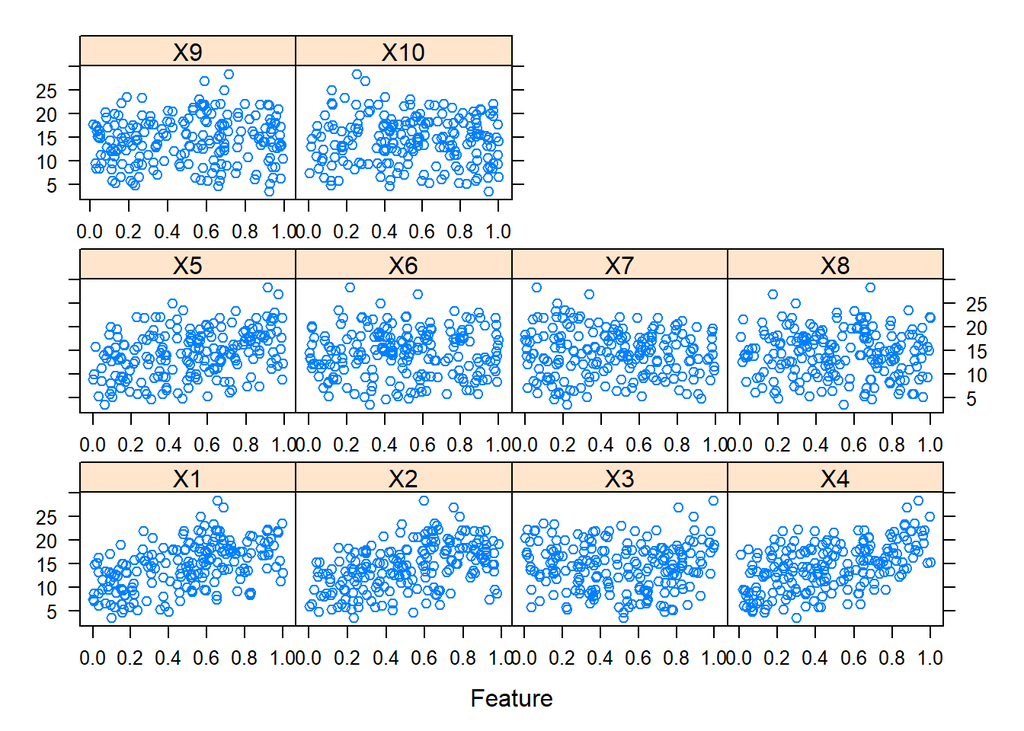

```r
library(mlbench)
set.seed(200)
trainingData <- mlbench.friedman1(200, sd = 1)
  ## We convert the 'x' data from a matrix to a data frame
## One reason is that this will give the columns names.
trainingData$x <- data.frame(trainingData$x)
## Look at the data using
featurePlot(trainingData$x, trainingData$y)
```

```r
## or other methods.
## This creates a list with a vector 'y' and a matrix
## of predictors 'x'. Also simulate a large test set to
## estimate the true error rate with good precision:
testData <- mlbench.friedman1(5000, sd = 1)
testData$x <- data.frame(testData$x)
```

Tune several models on these data. For example:

```r
library(caret)
knnModel <- train(x = trainingData$x,
                  y = trainingData$y,
                  method = "knn",
                  preProc = c("center", "scale"),
                  tuneLength = 10)

knnModel
```

```
## k-Nearest Neighbors
##
## 200 samples
##  10 predictor
##
## Pre-processing: centered (10), scaled (10)
## Resampling: Bootstrapped (25 reps)
## Summary of sample sizes: 200, 200, 200, 200, 200, 200, ...
## Resampling results across tuning parameters:
##
##   k   RMSE      Rsquared   MAE
##    5  3.466085  0.5121775  2.816838
##    7  3.349428  0.5452823  2.727410
##    9  3.264276  0.5785990  2.660026
##   11  3.214216  0.6024244  2.603767
##   13  3.196510  0.6176570  2.591935
##   15  3.184173  0.6305506  2.577482
##   17  3.183130  0.6425367  2.567787
##   19  3.198752  0.6483184  2.592683
##   21  3.188993  0.6611428  2.588787
##   23  3.200458  0.6638353  2.604529
##
## RMSE was used to select the optimal model using the smallest value.
## The final value used for the model was k = 17.
```

```r
knnPred <- predict(knnModel, newdata = testData$x)
postResample(pred = knnPred, obs = testData$y)
```

```
##      RMSE  Rsquared       MAE
## 3.2040595 0.6819919 2.5683461
```

#### Neural Network Model

```r
nnetFit
```

```
## Model Averaged Neural Network with 5 Repeats
##
## a 10-5-1 network with 61 weights
## options were - linear output units  decay=0.01
```

```r
nnetPred <- predict(nnetFit, newdata = testData$x)
postResample(pred = nnetPred, obs = testData$y)
```

```
##      RMSE  Rsquared       MAE
## 1.7760172 0.8732967 1.3436096
```

#### Multivariate Adaptive Regression Splines

```r
library(earth)
marsGrid <- expand.grid(.degree = 1:2, .nprune = 2:38)
marsTuned <- train(x = trainingData$x,
                   y = trainingData$y,
                   method = "earth",
                   tuneGrid = marsGrid,
                   trControl = trainControl(method = "cv"))
summary(marsTuned)
```

```
## Call: earth(x=data.frame[200,10], y=c(18.46,16.1,17...), keepxy=TRUE, degree=2,
##             nprune=12)
##
##                                 coefficients
## (Intercept)                        22.050690
## h(0.621722-X1)                    -15.001651
## h(X1-0.621722)                     10.878737
## h(0.601063-X2)                    -18.830135
## h(0.447442-X3)                      9.940077
## h(X3-0.606015)                     12.999390
## h(0.734892-X4)                     -9.877554
## h(X4-0.734892)                     10.414930
## h(0.850094-X5)                     -5.604897
## h(X1-0.621722) * h(X2-0.295997)   -43.245766
## h(0.649253-X1) * h(0.601063-X2)    26.218297
##
## Selected 11 of 18 terms, and 5 of 10 predictors
## Termination condition: Reached nk 21
## Importance: X1, X4, X2, X5, X3, X6-unused, X7-unused, X8-unused, X9-unused, ...
## Number of terms at each degree of interaction: 1 8 2
## GCV 1.747495    RSS 264.5358    GRSq 0.929051    RSq 0.9457576
```

```r
marsPred <- predict(marsTuned, newdata = testData$x)
postResample(pred = marsPred, obs = testData$y)
```

```
##      RMSE  Rsquared       MAE
## 1.2803060 0.9335241 1.0168673
```

#### Support Vector Machines

```r
library(kernlab)
svmRTuned <- train(x = trainingData$x,
                   y = trainingData$y,
                   method = "svmRadial",
                   preProc = c("center", "scale"),
                   tuneLength = 14,
                   trControl = trainControl(method = "cv"))
svmRTuned
```

```
## Support Vector Machines with Radial Basis Function Kernel
##
## 200 samples
##  10 predictor
##
## Pre-processing: centered (10), scaled (10)
## Resampling: Cross-Validated (10 fold)
## Summary of sample sizes: 180, 180, 180, 180, 180, 180, ...
## Resampling results across tuning parameters:
##
##   C        RMSE      Rsquared   MAE
##      0.25  2.530435  0.7901963  2.004487
##      0.50  2.255696  0.8090387  1.792581
##      1.00  2.093099  0.8300166  1.660175
##      2.00  2.008122  0.8446842  1.571400
##      4.00  1.946207  0.8556897  1.519964
##      8.00  1.905850  0.8611268  1.505200
##     16.00  1.907569  0.8600929  1.509775
##     32.00  1.907569  0.8600929  1.509775
##     64.00  1.907569  0.8600929  1.509775
##    128.00  1.907569  0.8600929  1.509775
##    256.00  1.907569  0.8600929  1.509775
##    512.00  1.907569  0.8600929  1.509775
##   1024.00  1.907569  0.8600929  1.509775
##   2048.00  1.907569  0.8600929  1.509775
##
## Tuning parameter 'sigma' was held constant at a value of 0.06431588
## RMSE was used to select the optimal model using the smallest value.
## The final values used for the model were sigma = 0.06431588 and C = 8.
```

```r
svmPred <- predict(svmRTuned, newdata = testData$x)
postResample(pred = svmPred, obs = testData$y)
```

```
##      RMSE  Rsquared       MAE
## 2.0596874 0.8281385 1.5633494
```

The Multivariate Adaptive Regression Splines model produces the lowest RMSE, highest Rsquared, and lowest MAE. The MARS model selected 5 out of 10 predictors (X1-X5); these are all the informative predictors.

## Question 7.5

Exercise 6.3 describes data for a chemical manufacturing process. Use the same data imputation, data splitting, and pre-processing steps as before and train several nonlinear regression models.

```r
data(ChemicalManufacturingProcess)
cmp <- ChemicalManufacturingProcess[, -nearZeroVar(ChemicalManufacturingProcess)]

#kNN imputation will be used to fill the missing values in the dataset.
cmp <- preProcess(as.data.frame(cmp), method = "knnImpute", k = 10)$data

# test train split
set.seed(0)
smp_size <- floor(0.8 * nrow(cmp))
train_ind <- sample(seq_len(nrow(cmp)), size = smp_size)

Xtrain <- cmp[train_ind, -1]
Xtest <- cmp[-train_ind, -1]

ytrain <- cmp[train_ind, 1]
ytest <- cmp[-train_ind, 1]
```

1. Which nonlinear regression model gives the optimal resampling and test set performance?

#### K Nearest Neighbor

```r
knnModel <- train(x = Xtrain,
                  y = ytrain,
                  method = "knn",
                  preProc = c("center", "scale"),
                  tuneLength = 10)

knnModel
```

```
## k-Nearest Neighbors
##
## 121 samples
##  56 predictor
##
## Pre-processing: centered (56), scaled (56)
## Resampling: Bootstrapped (25 reps)
## Summary of sample sizes: 121, 121, 121, 121, 121, 121, ...
## Resampling results across tuning parameters:
##
##   k   RMSE       Rsquared   MAE
##    5  0.7915034  0.4601246  0.6280008
##    7  0.8044428  0.4440399  0.6386233
##    9  0.8009274  0.4583975  0.6395943
##   11  0.8034349  0.4623691  0.6448591
##   13  0.8049449  0.4666385  0.6474978
##   15  0.8136250  0.4576535  0.6541549
##   17  0.8199790  0.4567221  0.6611276
##   19  0.8240740  0.4602510  0.6647304
##   21  0.8328735  0.4565277  0.6720905
##   23  0.8394308  0.4560071  0.6778361
##
## RMSE was used to select the optimal model using the smallest value.
## The final value used for the model was k = 5.
```

```r
knnPred <- predict(knnModel, newdata = Xtest)
postResample(pred = knnPred, obs = ytest)
```

```
##      RMSE  Rsquared       MAE
## 0.6970735 0.4128862 0.5354828
```

#### Neural Network Model

```r
nnetFit
```

```
## Model Averaged Neural Network with 5 Repeats
##
## a 56-5-1 network with 291 weights
## options were - linear output units  decay=0.01
```

```r
nnetPred <- predict(nnetFit, newdata = Xtest)
postResample(pred = nnetPred, obs = ytest)
```

```
##      RMSE  Rsquared       MAE
## 0.6555705 0.5444447 0.5087601
```

#### Multivariate Adaptive Regression Splines

```r
library(earth)
marsGrid <- expand.grid(.degree = 1:2, .nprune = 2:38)
marsTuned <- train(x = Xtrain,
                   y = ytrain,
                   method = "earth",
                   tuneGrid = marsGrid,
                   trControl = trainControl(method = "cv"))
summary(marsTuned)
```

```
## Call: earth(x=data.frame[121,56], y=c(-1.011,0.446,...), keepxy=TRUE, degree=2,
##             nprune=7)
##
##                                                                           coefficients
## (Intercept)                                                                 -0.4517631
## h(-0.090604-ManufacturingProcess09)                                         -0.5310012
## h(-0.401815-ManufacturingProcess13)                                          0.7457923
## h(ManufacturingProcess32- -0.827442)                                         0.4893506
## h(ManufacturingProcess39-0.165304)                                          -2.5426673
## h(BiologicalMaterial12- -0.219621) * h(ManufacturingProcess09- -0.090604)    0.4452104
## h(0.744561-ManufacturingProcess28) * h(ManufacturingProcess32- -0.827442)    0.2471084
##
## Selected 7 of 42 terms, and 6 of 56 predictors
## Termination condition: RSq changed by less than 0.001 at 42 terms
## Importance: ManufacturingProcess32, ManufacturingProcess09, ...
## Number of terms at each degree of interaction: 1 4 2
## GCV 0.3336436    RSS 30.40017    GRSq 0.6995123    RSq 0.7699391
```

```r
marsPred <- predict(marsTuned, newdata = Xtest)
postResample(pred = marsPred, obs = ytest)
```

```
##      RMSE  Rsquared       MAE
## 0.6141105 0.5736586 0.5134494
```

#### Support Vector Machines

```r
library(kernlab)
svmRTuned <- train(x = Xtrain,
                   y = ytrain,
                   method = "svmRadial",
                   preProc = c("center", "scale"),
                   tuneLength = 14,
                   trControl = trainControl(method = "cv"))
svmRTuned
```

```
## Support Vector Machines with Radial Basis Function Kernel
##
## 121 samples
##  56 predictor
##
## Pre-processing: centered (56), scaled (56)
## Resampling: Cross-Validated (10 fold)
## Summary of sample sizes: 109, 108, 109, 109, 108, 109, ...
## Resampling results across tuning parameters:
##
##   C        RMSE       Rsquared   MAE
##      0.25  0.8302541  0.4672792  0.6777092
##      0.50  0.7646354  0.5227493  0.6194463
##      1.00  0.7271215  0.5691309  0.5957993
##      2.00  0.6741144  0.6215252  0.5553700
##      4.00  0.6558508  0.6237964  0.5336353
##      8.00  0.6500105  0.6235019  0.5257665
##     16.00  0.6488643  0.6254285  0.5241727
##     32.00  0.6488643  0.6254285  0.5241727
##     64.00  0.6488643  0.6254285  0.5241727
##    128.00  0.6488643  0.6254285  0.5241727
##    256.00  0.6488643  0.6254285  0.5241727
##    512.00  0.6488643  0.6254285  0.5241727
##   1024.00  0.6488643  0.6254285  0.5241727
##   2048.00  0.6488643  0.6254285  0.5241727
##
## Tuning parameter 'sigma' was held constant at a value of 0.01208728
## RMSE was used to select the optimal model using the smallest value.
## The final values used for the model were sigma = 0.01208728 and C = 16.
```

```r
svmPred <- predict(svmRTuned, newdata = Xtest)
postResample(pred = svmPred, obs = ytest)
```

```
##      RMSE  Rsquared       MAE
## 0.4799170 0.7235624 0.4032473
```

The SVM model produces the best results when resampling on the test set, which a much higher R-squared and lower RMSE than the other models.

2. Which predictors are most important in the optimal nonlinear regression model? Do either the biological or process variables dominate the list? How do the top ten important predictors compare to the top ten predictors from the optimal linear model?

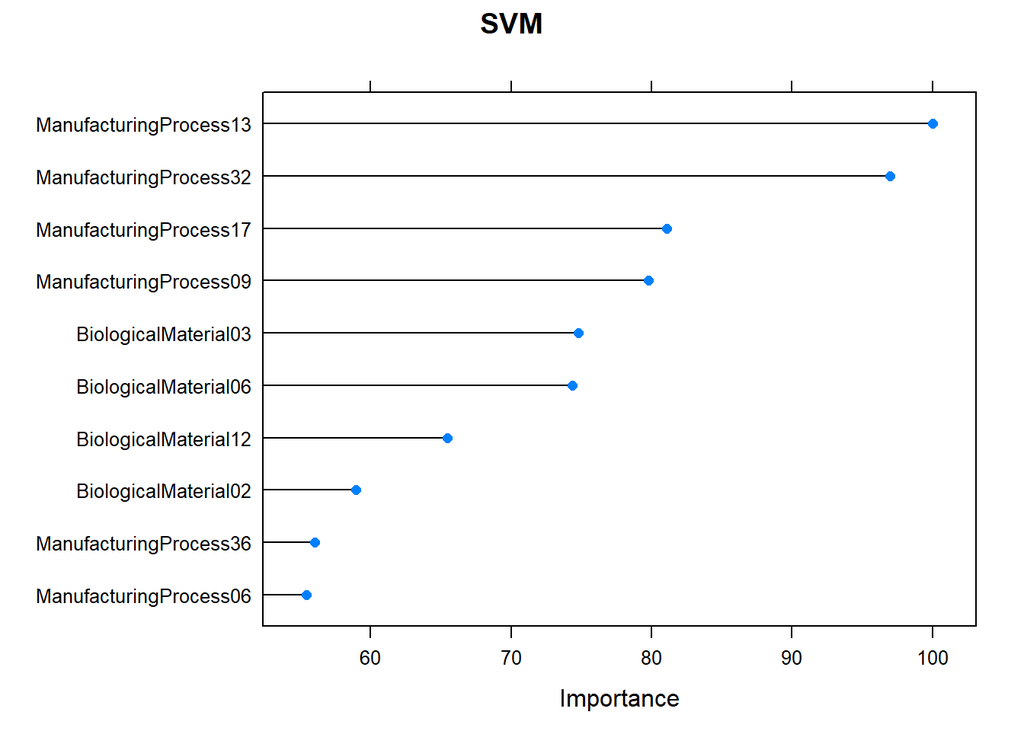

```r
plsTune <- train(Xtrain,
                 ytrain,
                 method = "pls",
                 tuneLength = 30,
                 preProc = c("center", "scale"),
                 trControl =  trainControl(method = 'cv', 10))

plot(varImp(svmRTuned), top = 10, main = "SVM")
```

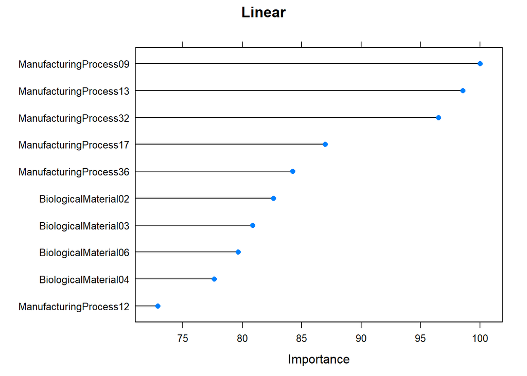

```r
plot(varImp(plsTune), top = 10, main = "Linear")
```

3. Explore the relationships between the top predictors and the response for the predictors that are unique to the optimal nonlinear regression model. Do these plots reveal intuition about the biological or process predictors and their relationship with yield?

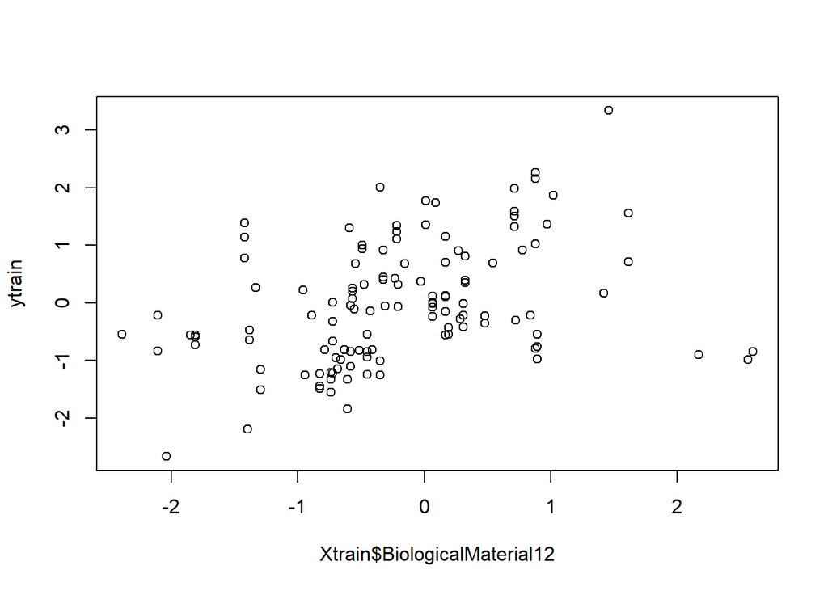

```r
plot(Xtrain$BiologicalMaterial12, ytrain)
```